# awesomlab4: A linear regression package

Martin Svensson and Laura Julià Melis

## 1. Introduction.

The **awesomelab4** package contains an object with class linreg, created with the RC object oriented system. This object is helpful to handle linear regression models as it provides multiple methods such as `resid()` and `coef()` to obtain the vector of residuals and the regressions coefficients of a given regression model, respectively.

## 2. Statistics calculations.

By default, tha class object calculates various statistics and stores them. This section aims to briefly explain these estimations. Let $\boldsymbol{X}$ be the matrix of independent variables and $\boldsymbol{y}$ the vector with the dependent variable values, then `linreg()` will estimate the following:

**i. Regressions coefficients:**
$$\hat{\beta}=(\boldsymbol{X}^{\boldsymbol{T}}\boldsymbol{X})^{-1} \boldsymbol{X}^{\boldsymbol{T}}\boldsymbol{y}$$
**ii. The fitted values:**
$$\hat{\boldsymbol{y}}= \boldsymbol{X}\hat{\beta}$$
**iii. The residuals:**
$$\boldsymbol{\hat{e}}= \boldsymbol{y}-\boldsymbol{\hat{y}}= \boldsymbol{y}- \boldsymbol{X}\hat{\beta}$$
**iv. The degrees of freedom:**
$$df=n-p$$
where $n$ is the number of observations and $p$ is the number of parameters in the model.

**v. The residual variance:**
$$\hat{\sigma}^2=\frac{\boldsymbol{e}^\boldsymbol{T}\boldsymbol{e}}{df}$$
**vi. The variance of the regression coefficients:**
$$\widehat{\boldsymbol{Var}}(\hat{\beta})=\hat{\sigma}^2(\boldsymbol{X}^{\boldsymbol{T}}\boldsymbol{X})^{-1}$$
**vii. The t-values for each coefficient:**
$$t_{\beta}=\frac{\hat{\beta}}{\sqrt{Var(\hat{\beta})}}$$

## 3. linreg( ) description.

The class object `linreg()` stores the statistics seen in the section above as *fields* and contains multiple functions (*methods*) to obtain outputs related to linear regression models. The name and a brief description of each one is listed below.

**1. Fields.**

- `formula:` an object of class “formula”.
- `data:` a data frame.
- `regression_coefficients:` the regression coefficients of the model calculated using the QR decomposition.
- `fitted_values:` the fitted values.
- `residuals:` the residuals. It is the difference between the real values and the fitted values.
- `degrees_of_freedom:` the degrees of freedom: the number of observations minus the number of parameters in the model.
- `residual_variance:` the residual variance.
- `variance_of_coefficients:` the variance of the regression coefficients.
- `std_error:` the standard error of the regression coefficients. It is the square root of the variance.
- `t_values:` the t-values for each coefficient.
- `p_values:` the p-values for each coefficient.

## 4. Example.

This section shows how to use `linreg()` on a well known dataset such as iris.

### Initialization.

```r
# Loading the dataset.
data(iris)

# Setting "formula" and "data" arguments
linreg_mod <- linreg$new(Petal.Length~Sepal.Width+Sepal.Length, data=iris)
```

### Methods.

**print()**

```r
linreg_mod$print()
```

```
## $Call
## [1] "linreg(formula = Petal.Length ~ Sepal.Width + Sepal.Length, data = iris)"
##
## $Coefficients
##      (Intercept) Sepal.Width Sepal.Length
## [1,]   -2.524762   -1.338623     1.775593
```

**plot()**

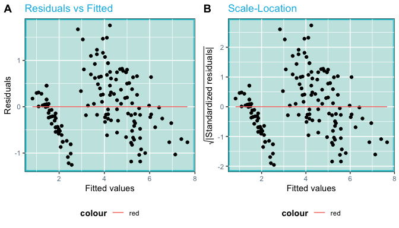

```r
plot1 <- linreg_mod$plot()
plot1
```

**resid()**

```r
head(linreg_mod$resid())
```

```
##           [,1]
## 1 -0.445578965
## 2 -0.759772100
## 3 -0.236928933
## 4  0.006767993
## 5 -0.134157381
## 6 -0.142807413
```

**pred()**

```r
head(linreg_mod$pred())
```

```
##       [,1]
## 1 1.845579
## 2 2.159772
## 3 1.536929
## 4 1.493232
## 5 1.534157
## 6 1.842807
```

**coef()**

```r
linreg_mod$coef()
```

```
## [1] -2.524762 -1.338623  1.775593
```

## References.

- Reference Classes: http://adv-r.had.co.nz/R5.html
- QR decomposition: https://en.wikipedia.org/wiki/QR_decomposition
- Vignettes: http://r-pkgs.had.co.nz/vignettes.html